# Pre-processing

PS239T

Fall 2015

### Setup Environment

First let’s load our required packages.

```r
setwd("~/Dropbox/berkeley/Dissertation/Data and Analyais/Git Repos/text-analysis-dhbsi")
rm(list=ls())
library(tm) # Framework for text mining
library(RTextTools) # a machine learning package for text classification written in R
library(qdap) # Quantiative discourse analysis of transcripts
library(qdapDictionaries)
library(dplyr) # Data preparation and pipes $>$
library(ggplot2) # for plotting word frequencies
library(SnowballC) # for stemming
```

# 1. Reading a Corpus

### 1.1 What is a Corpus

A corpus is a collection of texts, usually stored electronically, and from which we perform our analysis. A corpus might be a collection of news articles from Reuters or the published works of Shakespeare.

Within each corpus we will have separate articles, stories, volumes, each treated as a separate entity or record. Each unit is called a “document.”

Documents come in a variety of formats, but plain text is best.

For this unit, we will be using a section of Machiavelli’s Prince as our corpus. Since The Prince is a monograph, we have already “chunked” the text, so that each short paragraph or “chunk” is considered a “document.”

### 1.2 Corpus Sources and Readers

The `tm` package supports a variety of sources and formats.

```r
getSources()
```

```
## [1] "DataframeSource" "DirSource"       "URISource"       "VectorSource"
## [5] "XMLSource"       "ZipSource"
```

```r
getReaders()
```

```
##  [1] "readDOC"                 "readPDF"
##  [3] "readPlain"               "readRCV1"
##  [5] "readRCV1asPlain"         "readReut21578XML"
##  [7] "readReut21578XMLasPlain" "readTabular"
##  [9] "readTagged"              "readXML"
```

Here we’ll be going over two main options to input a corpus.

Option 1) We can read a corpus from a directory that contains text files, each document a different file.

```r
docs <- Corpus(DirSource("Data/MachText"))
docs
```

```
## <<VCorpus>>
## Metadata:  corpus specific: 0, document level (indexed): 0
## Content:  documents: 188
```

Option 2) We can read from a csv of documents, with each row being a document, and columns for text and metadata (information about each document). This is the easiest option if you have metadata.

```r
docs.df <-read.csv("Data/mach.csv", header=TRUE) #read in CSV file
docs <- Corpus(VectorSource(docs.df$text))
docs
```

```
## <<VCorpus>>
## Metadata:  corpus specific: 0, document level (indexed): 0
## Content:  documents: 188
```

### 1.3 Inspecting a Corpus

Once we have the corpus, we can inspect the documents using inspect()

```r
# see the 16th document
inspect(docs[16])
```

```
## <<VCorpus>>
## Metadata:  corpus specific: 0, document level (indexed): 0
## Content:  documents: 1
##
## [[1]]
## <<PlainTextDocument>>
## Metadata:  7
## Content:  chars: 885
```

And see the text using the `as.chracter`

```r
 # see content for 16th document
as.character(docs[[16]])
```

```
## [1] " Therefore, since a ruler cannot both practise this virtue of generosity and be known to do so without harming himself, he would do well not to worry about being called miserly. For eventually he will come to be considered more generous, when it is realised that, because of his parsimony, hi…
```

# 2. Preprocessing

Many text analysis applications follow a similar ‘recipe’ for preprecessing, involving:

1. Tokenizing the text to unigrams (or bigrams, or trigrams)
2. Converting all characters to lowercase
3. Removing punctuation
4. Removing numbers
5. Removing Stop Words, inclugind custom stop words
6. “Stemming” words, or lemmitization. There are several stemming alogrithms. Porter is the most popular.
7. Weighting features
8. Creating a Document-Term Matrix
9. Removing Sparse Terms

### 2.1 Basic Transformations

See what transformations are available TM package

```r
getTransformations()
```

```
## [1] "removeNumbers"     "removePunctuation" "removeWords"
## [4] "stemDocument"      "stripWhitespace"
```

The function `tm_map()` is used to apply one of these transformations across all documents.

We can basic transformations using the build in `tm_map` tools.

```r
docs <- tm_map(docs, content_transformer(tolower)) # convert all text to lower case
as.character(docs[[16]])
```

```
## [1] " therefore, since a ruler cannot both practise this virtue of generosity and be known to do so without harming himself, he would do well not to worry about being called miserly. for eventually he will come to be considered more generous, when it is realised that, because of his parsimony, hi…
```

```r
docs <- tm_map(docs, removePunctuation) # remove Puncturation
as.character(docs[[16]])
```

```
## [1] " therefore since a ruler cannot both practise this virtue of generosity and be known to do so without harming himself he would do well not to worry about being called miserly for eventually he will come to be considered more generous when it is realised that because of his parsimony his reve…
```

```r
docs <- tm_map(docs, removeNumbers) # remove Numbers
as.character(docs[[16]])
```

```
## [1] " therefore since a ruler cannot both practise this virtue of generosity and be known to do so without harming himself he would do well not to worry about being called miserly for eventually he will come to be considered more generous when it is realised that because of his parsimony his reve…
```

```r
docs <- tm_map(docs, removeWords, stopwords("english")) # remove common words
stopwords("english") # check out what was removed
```

```
##   [1] "i"          "me"         "my"         "myself"     "we"
##   [6] "our"        "ours"       "ourselves"  "you"        "your"
##  [11] "yours"      "yourself"   "yourselves" "he"         "him"
##  [16] "his"        "himself"    "she"        "her"        "hers"
##  [21] "herself"    "it"         "its"        "itself"     "they"
##  [26] "them"       "their"      "theirs"     "themselves" "what"
##  [31] "which"      "who"        "whom"       "this"       "that"
##  [36] "these"      "those"      "am"         "is"         "are"
##  [41] "was"        "were"       "be"         "been"       "being"
##  [46] "have"       "has"        "had"        "having"     "do"
##  [51] "does"       "did"        "doing"      "would"      "should"
##  [56] "could"      "ought"      "i'm"        "you're"     "he's"
##  [61] "she's"      "it's"       "we're"      "they're"    "i've"
##  [66] "you've"     "we've"      "they've"    "i'd"        "you'd"
##  [71] "he'd"       "she'd"      "we'd"       "they'd"     "i'll"
```

[output cut: 20 more lines]

```r
as.character(docs[[16]])
```

```
## [1] " therefore since  ruler   practise  virtue  generosity   known    without harming     well   worry   called miserly  eventually  will come   considered  generous    realised     parsimony  revenues  sufficient  defend    enemies  attack    undertake campaigns without imposing special taxes  …
```

```r
docs <- tm_map(docs, removeWords, c("prince")) # remove own stop words
as.character(docs[[16]])
```

```
## [1] " therefore since  ruler   practise  virtue  generosity   known    without harming     well   worry   called miserly  eventually  will come   considered  generous    realised     parsimony  revenues  sufficient  defend    enemies  attack    undertake campaigns without imposing special taxes  …
```

```r
docs <- tm_map(docs, stripWhitespace) # strip white space
as.character(docs[[16]])
```

```
## [1] " therefore since ruler practise virtue generosity known without harming well worry called miserly eventually will come considered generous realised parsimony revenues sufficient defend enemies attack undertake campaigns without imposing special taxes people thus will acting generously toward…
```

```r
docs <- tm_map(docs, stemDocument) # stem the document
as.character(docs[[16]])
```

```
## [1] " therefor sinc ruler practis virtu generos known without harm well worri call miser eventu will come consid generous realis parsimoni revenu suffici defend enemi attack undertak campaign without impos special tax peopl thus will act generous toward vast major whose properti touch will act me…
```

### 2.2 Custom Transformations

We can also use regular R functions for custom transformations using the `content_transformer()` function.

For example, we might want to replace “/”, used sometimes to separate alternative words, with a space. This will avoid the two words being run into one string of characters through the transformations. We might also replace “@” and “|” with a space, for the same reason

```r
# note: won't work on past versions of R
toSpace <- content_transformer(function(x, pattern) gsub(pattern, " ", x))
docs <- tm_map(docs, toSpace, "/")
docs <- tm_map(docs, toSpace, "@")
docs <- tm_map(docs, toSpace,"\\|")
as.character(docs[[16]])
```

```
## [1] " therefor sinc ruler practis virtu generos known without harm well worri call miser eventu will come consid generous realis parsimoni revenu suffici defend enemi attack undertak campaign without impos special tax peopl thus will act generous toward vast major whose properti touch will act me…
```

# 3. Document Term Matrices (DTM)

A document term matrix is simply a matrix with documents as the rows and terms as the columns and a count of the frequency of words as the cells of the matrix.

### 3.1 Creating the DTM

We use `DocumentTermMatrix()` to create the matrix:

```r
dtm <- DocumentTermMatrix(docs)
dtm
```

```
## <<DocumentTermMatrix (documents: 188, terms: 2365)>>
## Non-/sparse entries: 11750/432870
## Sparsity           : 97%
## Maximal term length: 15
## Weighting          : term frequency (tf)
```

`tm` also lets us convert a corpus to a DTM while completing the pre-processing steps in one step.

```r
dtm <- DocumentTermMatrix(docs,
           control = list(stopwords = TRUE,
                          tolower = TRUE,
                          removeNumbers = TRUE,
                          removePunctuation = TRUE,
                          stemming=TRUE))
```

### 3.2 Special Weights and Scaling

One common pre-processing step that some applicaitons may call for is applying tf-idf weights. The [tf-idf](https://en.wikipedia.org/wiki/Tf%E2%80%93idf), or term frequency-inverse document frequency, is a weight that ranks the importance of a term in its contextual document corpus. The tf-idf value increases proportionally to the number of times a word appears in the document, but is offset by the frequency of the word in the corpus, which helps to adjust for the fact that some words appear more frequently in general. In other words, it places importance on terms frequent in the document but rare in the corpus.

We won’t be using tf-idf weghts for the rest of the unit, but you should know about it for other applications.

```r
dtm.weighted <- DocumentTermMatrix(docs,
           control = list(weighting =function(x) weightTfIdf(x, normalize = TRUE),
                          stopwords = TRUE,
                          tolower = TRUE,
                          removeNumbers = TRUE,
                          removePunctuation = TRUE,
                          stemming=TRUE))
```

# 4. Exploring the DTM

Let’s look at the structure of our DTM.

```r
# how many documents? how many terms?
dim(dtm)
```

```
## [1]  188 2354
```

```r
# take a quick look
inspect(dtm[1:5,1000:1005])
```

```
## <<DocumentTermMatrix (documents: 5, terms: 6)>>
## Non-/sparse entries: 1/29
## Sparsity           : 97%
## Maximal term length: 9
## Weighting          : term frequency (tf)
##
##     Terms
## Docs highest hill himselfin hinder histor histori
##    1       0    0         0      0      0       1
##    2       0    0         0      0      0       0
##    3       0    0         0      0      0       0
##    4       0    0         0      0      0       0
##    5       0    0         0      0      0       0
```

```r
inspect(dtm.weighted[1:5,1000:1005])
```

```
## <<DocumentTermMatrix (documents: 5, terms: 6)>>
## Non-/sparse entries: 1/29
## Sparsity           : 97%
## Maximal term length: 9
## Weighting          : term frequency - inverse document frequency (normalized) (tf-idf)
##
##     Terms
## Docs highest hill himselfin hinder histor   histori
##    1       0    0         0      0      0 0.0624636
##    2       0    0         0      0      0 0.0000000
##    3       0    0         0      0      0 0.0000000
##    4       0    0         0      0      0 0.0000000
##    5       0    0         0      0      0 0.0000000
```

### 4.1 Most and Least Frequent Terms

We can obtain the term frequencies as a vector by converting the document term matrix into a matrix and summing the column counts:

```r
 # how many terms?
freq <- colSums(as.matrix(dtm))
length(freq)
```

```
## [1] 2354
```

By ordering the frequencies we can list the most frequent terms and the least frequent terms:

```r
# order
ord <- order(freq)

# Least frequent terms
freq[head(ord)]
```

```
##     abject     ablest   abovenam     absorb     access accomplish
##          1          1          1          1          1          1
```

```r
# most frequent
freq[tail(ord)]
```

```
##   men peopl   one power  will ruler
##    95    98   168   169   251   280
```

```r
# frequency of frenquencies
head(table(freq),15)
```

```
## freq
##   1   2   3   4   5   6   7   8   9  10  11  12  13  14  15
## 978 364 200 141 100  73  55  40  33  29  24  21  20  20  19
```

```r
tail(table(freq),15)
```

```
## freq
##  62  64  65  70  71  73  74  76  77  95  98 168 169 251 280
##   1   3   1   1   1   2   2   1   1   2   1   1   1   1   1
```

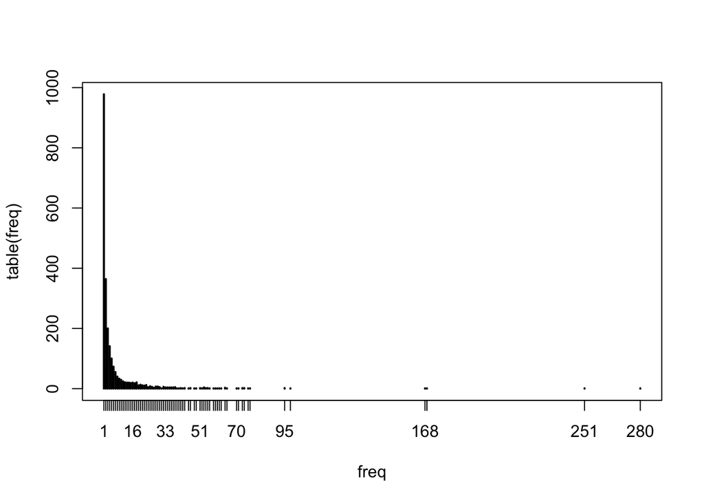

```r
# plot
plot(table(freq))
```

**Bonus**: reorder columns of DTM to show most frequent terms first

```r
dtm.ordered <- dtm[,order(freq, decreasing = T)]
inspect(dtm.ordered[1:5,1:5])
```

```
## <<DocumentTermMatrix (documents: 5, terms: 5)>>
## Non-/sparse entries: 10/15
## Sparsity           : 60%
## Maximal term length: 5
## Weighting          : term frequency (tf)
##
##     Terms
## Docs ruler will power one peopl
##    1     1    1     0   0     0
##    2     1    3     0   3     0
##    3     0    0     0   0     0
##    4     1    1     0   0     0
##    5     1    1     0   3     0
```

### 4.2 Exploring word frequences and correlations

```r
# Have a look at common words
findFreqTerms(dtm, lowfreq=100) # words that appear at least 100 times
```

```
## [1] "one"   "power" "ruler" "will"
```

```r
# Which words correlate with "war"?
findAssocs(dtm, "war", 0.3)
```

```
## $war
##     wage    fight  antioch     argu     brew    induc      lip    maxim
##     0.73     0.52     0.45     0.45     0.45     0.45     0.45     0.45
##  relianc     sage    trifl  postpon     mere     evil    avoid     flee
##     0.45     0.45     0.45     0.41     0.35     0.34     0.32     0.32
##   occupi     glad glorious    heard     hunt ineffect     knew   produc
##     0.32     0.30     0.30     0.30     0.30     0.30     0.30     0.30
##  tempori
##     0.30
```

```r
# plot the most frequent words
freq <- sort(colSums(as.matrix(dtm)),decreasing=TRUE)
head(freq)
```

```
## ruler  will power   one peopl alway
##   280   251   169   168    98    95
```

```r
wf <- data.frame(word=names(freq), freq=freq)
head(wf)
```

```
##        word freq
## ruler ruler  280
## will   will  251
## power power  169
## one     one  168
## peopl peopl   98
## alway alway   95
```

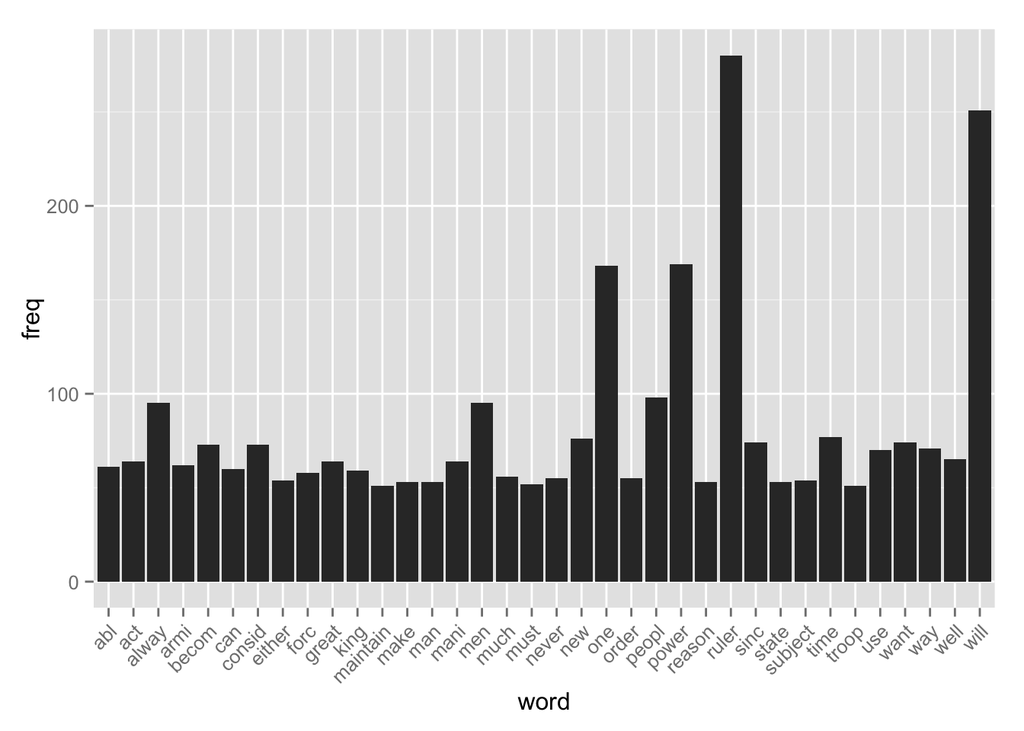

```r
subset(wf, freq>50) %>%
  ggplot (aes(word, freq)) +
  geom_bar (stat ="identity") +
  theme(axis.text.x=element_text(angle=45,hjust=1))
```

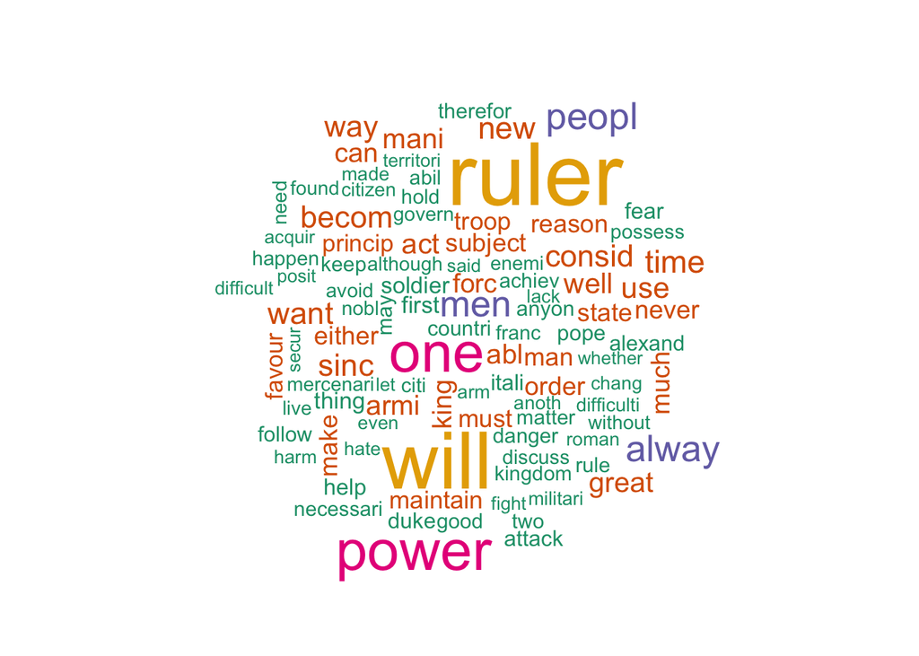

```r
# wordcoulds!
library(wordcloud)
set.seed(123)
wordcloud(names(freq), freq, max.words=100, colors=brewer.pal(6,"Dark2"))
```

### 4.3 Removing Sparse Terms

We can remove sparse terms and thus inrease efficency

```r
dtm.s <- removeSparseTerms(dtm,.99)
dtm # 2365 terms
```

```
## <<DocumentTermMatrix (documents: 188, terms: 2354)>>
## Non-/sparse entries: 11679/430873
## Sparsity           : 97%
## Maximal term length: 15
## Weighting          : term frequency (tf)
```

```r
dtm.s # 1326 terms
```

```
## <<DocumentTermMatrix (documents: 188, terms: 1323)>>
## Non-/sparse entries: 10648/238076
## Sparsity           : 96%
## Maximal term length: 13
## Weighting          : term frequency (tf)
```

# 5 Exporting the DTM

We can convert a DTM to a matrix or data.frame in order to write to a csv, add meta data, etc.

```r
# coerce into dataframe
dtm <- as.data.frame(as.matrix(dtm))
names(docs)  # names of documents
```

```
##   [1] "1"   "2"   "3"   "4"   "5"   "6"   "7"   "8"   "9"   "10"  "11"
##  [12] "12"  "13"  "14"  "15"  "16"  "17"  "18"  "19"  "20"  "21"  "22"
##  [23] "23"  "24"  "25"  "26"  "27"  "28"  "29"  "30"  "31"  "32"  "33"
##  [34] "34"  "35"  "36"  "37"  "38"  "39"  "40"  "41"  "42"  "43"  "44"
##  [45] "45"  "46"  "47"  "48"  "49"  "50"  "51"  "52"  "53"  "54"  "55"
##  [56] "56"  "57"  "58"  "59"  "60"  "61"  "62"  "63"  "64"  "65"  "66"
##  [67] "67"  "68"  "69"  "70"  "71"  "72"  "73"  "74"  "75"  "76"  "77"
##  [78] "78"  "79"  "80"  "81"  "82"  "83"  "84"  "85"  "86"  "87"  "88"
##  [89] "89"  "90"  "91"  "92"  "93"  "94"  "95"  "96"  "97"  "98"  "99"
## [100] "100" "101" "102" "103" "104" "105" "106" "107" "108" "109" "110"
## [111] "111" "112" "113" "114" "115" "116" "117" "118" "119" "120" "121"
## [122] "122" "123" "124" "125" "126" "127" "128" "129" "130" "131" "132"
## [133] "133" "134" "135" "136" "137" "138" "139" "140" "141" "142" "143"
## [144] "144" "145" "146" "147" "148" "149" "150" "151" "152" "153" "154"
## [155] "155" "156" "157" "158" "159" "160" "161" "162" "163" "164" "165"
## [166] "166" "167" "168" "169" "170" "171" "172" "173" "174" "175" "176"
## [177] "177" "178" "179" "180" "181" "182" "183" "184" "185" "186" "187"
## [188] "188"
```

```r
# add fake column for section
dtm$doc_section <- "NA"
dtm$doc_section[1:100] <- "Section 1"
dtm$doc_section[101:188] <- "Section 2"
dtm$doc_section <- as.factor(dtm$doc_section)

# check to see if they're the same number of documents per author
summary(dtm$doc_section)
```

```
## Section 1 Section 2
##       100        88
```

# 6. Bonus: rTextTools

```r
# Read corpus directly from dir and convert to data.frame.
docs <- Corpus(DirSource("Data/MachText"))
docs.df<-data.frame(text=unlist(sapply(docs, `[`, "content")),
    stringsAsFactors=F)
```

If you read in your corpus as a CSV, you should already have a dataframe (in this case, `docs.df`) in your environment.

```r
# Read corpus from csv
docs.df <- read.csv("Data/mach.csv")
```

Now we can make out DTM in one step.

```r
# Convert to DTM
dtm <- create_matrix(docs.df$text, language="english", removeNumbers=TRUE,
                       stemWords=TRUE, toLower = TRUE, removePunctuation = TRUE)
```

### Execise: Make a DTM out of your own corpus or one of the toy copora.